# pyp_1

#### *1. 交互与快捷键*

- **Ctrl + O** 打开文件 -- **Ctrl + N**新建文件 -- **Ctrl + Tab**跳转到文件
- **Ctrl + 1** 插入/取消注释 -- **Ctrl + 4** 插入块注释 -- **Ctrl + 5** 取消块注释
- **Crtl + Z** 撤销上一步操作 -- **Ctrl + Alt + ↑/1** 复制当前行至上一行 -- **Ctrl + Alt + ↓/2** 复制当前行至下一行 -- **Ctrl + D** 删除当前行
- F5 运行程序 -- Home 光标移至行首 -- End 光标移至行尾
- Ctrl + ← 光标移至单词前 -- Ctrl + → 标移至单词后 -- Ctrl + ↑ 光标移至代码块前 -- Ctrl + ↓ 光标移至代码块后
- Ctrl + Home 光标移至文档最前 -- Ctrl + end 光标移至文档最后 -- Ctrl + Backspace 删除前一个单词 -- Ctrl + Delete 删除后一个单词
- Ctrl + L 跳转到行 -- Ctrl + G 跳转到定义处 -- Ctrl + F 搜索文本 -- Ctrl + R 替换文本
- F3 搜索下一个文本 -- Shift + F3 搜索上一个文本 -- Ctrl + U 转换为小写-- Ctrl + Shift + U 转换为大写-- Ctrl + I 查看对象文档 -- F11 全屏模式-- F9 运行选择或当前行 -- Ctrl + Enter 运行当前代码段
- Ctrl + F5 启动调试 -- Ctrl + F12 调试继续 -- Ctrl + Shift + F12 停止调试 -- Ctrl + . 重启 Ipython 核 -- Ctrl + T 打开新的 Ipython 控制台

#### *2. 编程基础*

##### **2.1 变量及内存管理**

```python
a = 1
b = 1
id(a)

home = 0
home = home + 1
print(home)
```

```
1
```

##### **2.2 数学运算**

- 算数运算符/加法/减法/乘法/实数除法/整数除法/求余数/幂运算

```python
home = 5
home += 1
print (home)
home %= 4
print (home)
```

```
6
2
```

- 关系运算符
  - < 小于
  - <= 小于等于
  - != 不等于
  - == 完全等于
  - and 与
  - or 或
  - not 非

```python
tom = 18
H = 160
r = tom>=18 or H>150
print(r)
```

```
True
```

##### **2.3 编写交互式程序**

- 输入-处理-输出

```python
a = input() # '123'
a = int(a)
print(a)
```

```
123
```

##### **2.4 编写程序-注释**

- 使用\和()续行

```python
x = 3
y = 5
result_1 = x * 5 \
        + y
result_2 = (x * 5
         + y)
print(result_1)
print(result_2)
```

```
20
20
```

#### *3. 数据类型*

##### **3.1 数字**

- int()
- float()
- complex()

```python
first = 123
type(first)
pi = 3.1415
```

- arange(开始，结束，步长)

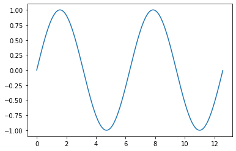

```python
import numpy as np
import matplotlib.pyplot as plt

x = np.arange(0, 4*np.pi, 0.01)
y = np.sin(x)

plt.plot(x,y)
plt.show()
```

##### **3.2 字符串**

- \n 换行
- \t 缩进
- \ 反普通符号
- \ 后面变原始符号
- 原始字符串 r'' 所有字符串不变

```python
say = 'tom:"let\\\'s go" \njerry:"ok"'
print(say)
print('=============')
say2 ='tom:"let\'s go" \njerry:"ok"\n'
print(say2)
```

```
tom:"let\'s go"
jerry:"ok"
=============
tom:"let's go"
jerry:"ok"
```

```python
# 字符串拼接
a = 1
b = '1'
# a + b
a + int(b)
str(a) + b
b*5
```

```
'11111'
```

##### **3.3 字符串分片和索引**

```python
s1 = 'hello'
s2 = 'hello world'

print(s1 in s2) # 必须是字符串
# print(w in s2) w只是一个变量

'w' in s2
'w' in s1

s1 == s2

if s1 == s2:
    print('ok')

if s1 != s2:
    print('okay')

if s1 not in s2:
    print ('ok')
```

```
True
okay
```

- 字符串切割和索引
- **String[i:j:k]** 不包含结束值

```python
print(s2[0:5])
print(s2[0:4])

print(s2[6:])
print(s2[:5])
print(s2[-5:])

print(s2[::1])
print(s2[::2])
print(s2[1:7:2])
```

```
hello
hell
world
hello
world
hello world
hlowrd
el
```

- 格式化字符串
- **含有%s/%d的字符串(a,b,c)**
- **%s** 字符串内用%s或者%d等占位
- **%d** “对应的值”

```python
say3 = 'there are %d monkey in the %s!'
print(say3)
say3 % (3,'tree')
print(say3 % (3,'tree'))

d1 = (3, 'tree')
d2 = (5, 'water')
print(say3 % d1)
print(say3 % d2)
```

```
there are %d monkey in the %s!
there are 3 monkey in the tree!
there are 3 monkey in the tree!
there are 5 monkey in the water!
```

##### **3.4 字符串方法**

- 每个类型都有具体的对象
  - int 8
  - float 3.14
  - complex 3+4j
  - Str "hello"
  - help()/help(str)

```python
say3 = 'there are %d monkey in the %s!'
newsay3 = say3.capitalize()
print(newsay3)
print(say3.count('e')) # 数出现了几次
```

```
There are %d monkey in the %s!
5
```

```python
hw = 'hello world'
print(hw.find('world')) # 找需要的词在第几位
print(hw[6:])
```

```
6
world
```

```python
ip = '192.168.1.123'
ip2 = '192.168.1.12'
ip3 = '192.168.1.1'

ipl = ip.split('.') # 用.切割字符串
print(ipl)
ipj = ".".join(ipl) # 用.连接字符串
print(ipj)
ipj1 = "----".join(ipl) # 用----连接字符串
print(ipj1)
```

```
['192', '168', '1', '123']
192.168.1.123
192----168----1----123
```

#### *4. 流程控制*

##### **4.1 布尔值与分支结构**

- Bool
- True: 非空对象(比如:string, tuple, list, set, dict)
- False: 0, None, 空的对象
- 作用: 一个字符串是否是空的，一个运算结果是否是0，一个表达式是否是0

```python
# =============================================================================
# if xxx:
#     []
# elif xxx:
#     []
# else:
#     []
# =============================================================================
a = int(input('please input your age:'))
w = int(input('please input your weight:'))

if a >= 18 and w >= 60:
    print('yes')
# elif a == '-':
#     print('-' * 5)
else:
    print('no')

# 多条件: and not or

x = input('please input:')

if not x:
    print('yes')
else:
    print('no')
```

```
yes
```

```
no
```

##### **4.2 循环**

```python
# =============================================================================
# for 迭代变量 in 序列: # range()
#     代码块
# =============================================================================
for i in 'hello':
    print(i)

# for x in range(5):
#     print(x)

# for x in range(1,10):
#     print(x)
num1 = []
for x in range(1,10,2):
    num1.append(x)
print(num1)
```

```
h
e
l
l
o
[1, 3, 5, 7, 9]
```

```python
# =============================================================================
# while 条件:
#     代码块
# =============================================================================
a = 'x'
while a != 'quit':
    a = input('input something:')
```

##### **4.3 嵌套和循环控制**

```python
# =============================================================================
# for 迭代变量 in 序列:
#     if 条件:
#         代码块
#     代码块
# =============================================================================
num2 = []
for i in range(1,6):
    if i > 3:
        num2.append(i * 10)
    num2.append(i)
print(num2)
```

```
[1, 2, 3, 40, 4, 50, 5]
```

- **循环控制**
  - continue 跳过当前余下的代码,返回执行前面的
  - break 立即跳出当前的循环
  - pass

```python
num3 = []
for i in range(1,6):
    if i == 3:
        num3.append(i * 10)
        continue # break/pass
        print(i * 2)
    num3.append(i)
print(num3)
```

```
[1, 2, 30, 4, 5]
```

```python
num = []
for i in range(1,10):
    if i == 5:
        num.append(i*10)
        continue
    if i == 7:
        break
    if i == 2:
        pass
    num.append(i)
print(num)
```

```
[1, 2, 3, 4, 50, 6]
```

```python
while 1:
    a = input('something:')
    if a == 'no':
        break
```

#### *5. 结构化数据类型*

##### **5.1 列表创建基本操作**

- 列表 []
- 元组 ()
- 字典 {}

```python
# 列表中可以是函数和类
player1 = ['milo', 100, 50]
milo = [100, 60, 0]

# 序列
print(milo[0])
print(player1[:2])
print(player1 + milo)
print(milo * 3)

# 遍历列表
for i in milo:
    print(i)
```

```
100
['milo', 100]
['milo', 100, 50, 100, 60, 0]
[100, 60, 0, 100, 60, 0, 100, 60, 0]
100
60
0
```

##### **5.2 列表常用方法**

- 列表: 可变性

```python
player1 = ['milo', 100, 50]
```

- **列表方法: 增删改查**
  - list.append(self, object) 增加元素在最后
  - list.insert(self, index, object) 在index前插入元素
  - list.extend(self, iterable) 扩展元素(列表中的元素依次增加)
  - list.pop(self, index) 删除列表某个下标
  - list.remove(self, object) 删除一个值
  - list.sort(self, key, reverse=False) 排序同种数据类型

```python
player1.append(10)
print(player1)
```

```
['milo', 100, 50, 10]
```

```python
player1.insert(1, 'male')
print(player1)
```

```
['milo', 'male', 100, 50, 10]
```

```python
box = ['a', 'b', 'c']
player1.extend(box)
print(player1)
player1.append(box)
print(player1)
```

```
['milo', 'male', 100, 50, 10, 'a', 'b', 'c']
['milo', 'male', 100, 50, 10, 'a', 'b', 'c', ['a', 'b', 'c']]
```

```python
player1.remove('a')
player1.remove('b')
print(player1)
```

```
['milo', 'male', 100, 50, 10, 'c', ['a', 'b', 'c']]
```

```python
player1.pop(-2)
print(player1)
x = player1.pop(-2)
print(x)
print(player1)
```

```
['milo', 'male', 100, 50, 10, ['a', 'b', 'c']]
10
['milo', 'male', 100, 50, ['a', 'b', 'c']]
```

```python
# 二元列表
print(player1[-1][0])
```

```
a
```

```python
box = [1,3,4,6,5,2]
box.sort(reverse=False)
print(box)
box.sort(reverse=True)
print(box)
```

```
[1, 2, 3, 4, 5, 6]
[6, 5, 4, 3, 2, 1]
```

- **相关方法**
  - range()
  - sorted()
  - str.split()
  - str.join(self, iterable)

```python
box = [1,3,4,6,5,2]
x = sorted(box)
print(x)
```

```
[1, 2, 3, 4, 5, 6]
```

##### **5.3 不可变的元组和灵活的列表**

- 列表: 可变性
- 元组-()
  - 创建(元素,元素,元素)
  - 拆分 x,y = (Value1,value2)

```python
t = ('x', 'y', 'z')
a,b,c = t
print(a,b,c)
print(t[-1], t[0])
```

```
x y z
z x
```

元组不可改变但是列表可以

```python
player1 = ['milo', 'male', 90, 50]
player1[1] = 'feamle'
```

##### **5.4 列表解析和生成表达式**

- 通过操作和处理一个序列(range等)来创建一个新的列表使用列表解析和生成表达式
- 1000以内能被3和5整除的数的和

```python
print(sum(range(1,10)))

nums = []
for i in range(1,50):
    if i%3 == 0 or i%5 ==0:
        nums.append(i)
print(nums)
print(sum(nums))
```

```
45
[3, 5, 6, 9, 10, 12, 15, 18, 20, 21, 24, 25, 27, 30, 33, 35, 36, 39, 40, 42, 45, 48]
543
```

- 列表解析的语法结构
- 在需要改变列表而不是创建列表时用列表解析
- 表达式:
  - [for iter_var in iterable]
  - [for iter_var in iterable if]

```python
# x = [i*10 for i in range(10)]
y = [i for i in range(1,1000) if i%3==0 or i%5==0]
print(sum(y))
```

```
233168
```

```python
# 生成器表达式
g = (i for i in range(1,10) if i%3==0 or i%5==0)
for i in g:
    print(i)

# 复制列表
L1 = list(y)
```

```
3
5
6
9
```

##### **5.5 字典创建基础操作**

- dictionary 是除了列表以外python之中灵活的内置数据结构类型
- 区别:字典中的元素是通过key来取得,无顺序

```python
player1 = ['milo', 100]
player1[0]
player1[1]
```

```
100
```

- 字典创建:dict2 = {'key':'value', 'key':'value'} 键值一一对应

```python
player1d = {'name':'milo', 'hp':100}
print(player1d)
print(player1d['hp'], player1d['name'])

d = {1:'a', 2:'b'}
print(d[1], d[2]) # 这里有数字是因为key是数字
```

```
{'name': 'milo', 'hp': 100}
100 milo
a b
```

- 属性:通过键来读取,任意对象的引用的集合,可变异构任意嵌套

```python
d[3] = 'c'
d[6] = 'c'
d[5] = 'c'
print(d)
```

```
{1: 'a', 2: 'b', 3: 'c', 6: 'c', 5: 'c'}
```

- 字典访问:
  - 通过key访问Value
  - dict['key']
  - 遍历 for key in dict:
    - print 'key=%s, value=%s' % (key,dict[key])
  - 方法 'key' in dict 或 dict.has_key('key')

```python
for k in d:
    print ('key=%s, value=%s' % (k,d[k]))
ok = 'name' in player1d
print(ok)
# dir(dict) # 查看方法
```

```
key=1, value=a
key=2, value=b
key=3, value=c
key=6, value=c
key=5, value=c
True
```

- 字典更新:
  - 覆盖更新:
    - dict['key'] = 'earth'
    - 更新dict['key'] = 'abc'

```python
d[5] = 'd'
d[6] = 'b'
print(d)
```

```
{1: 'a', 2: 'b', 3: 'c', 6: 'b', 5: 'd'}
```

- 删除字典和字典元素:
  - del dict2['name'] 删除键为name的条目
  - dict2.clear() 删除dict2中所有的条目
  - del dict2 删除整个dict2字典
  - dict2.pop('name') 删除并返回键为'name'的条目

```python
di = d.items()
print(di)

for k,v in di:
    print(k,'------>', v)
```

```
dict_items([(1, 'a'), (2, 'b'), (3, 'c'), (6, 'b'), (5, 'd')])
1 ------> a
2 ------> b
3 ------> c
6 ------> b
5 ------> d
```

##### **5.6 字典妙用switch**

- dictionary 是除了列表以外python之中灵活的内置数据结构类型
- 区别:字典中的元素是通过key来取得,无顺序

```python
x = int(input('first:'))
o = input('operator:')
y = int(input('second:'))

operator = {
            '+':x+y,
            '-':x-y,
            '*':x*y,
            '/':x/y
            }

# result = operator[o]
result = operator.get(o, 'please input +|-|*|/')
print(result)
```

```
7
```

##### **5.7 集合**

- 创建集合
  - 可变集合:set(iterable)
    - 特点: 无序排列且不重复，是可变的
    - 功能: 关系测试消除重复元素
  - 不可变集合:fronzenset(iterable)
    - 不可变
- x = set('hello')
- y = set('world')
- x & y = 交集
- x | y = 合集
- x - y = 补集